# myProj

Author

Iris Whetstone

## Hypothesis 1

Respondents with doctoral or equivalent professional degrees will have lower relationship satisfaction in their relationships.

### Variables and descriptive statistics

- **Degree Group (**`**degreeGroup**`**):** A categorical variable with two groups: doctoral/professional and other education. Other education describes any level of education reported below a doctoral/professional degree.

- **Relationship Satisfaction (**`**relSat**`**):** A composite variable including the average scores of each participant in a relationship’s responses to 7 point Likert-type scales asking for their relationship satisfaction, contentment, and happiness: `prqc_1`, `prqc_2`, `prqc_3`.

This dataset only includes respondents who were dating, in a commited relationship, or married.

```r
# Count respondents in each group.
table(h1Data$degreeGroup)
```

```
Doctoral/professional       Other education
                 3636                 47314
```

```r
# Summarize relationship satisfaction  separately for each group.
by(h1Data$relSat, h1Data$degreeGroup, summary)
```

```
h1Data$degreeGroup: Doctoral/professional
   Min. 1st Qu.  Median    Mean 3rd Qu.    Max.
  1.000   5.000   6.000   5.523   6.667   7.000
------------------------------------------------------------
h1Data$degreeGroup: Other education
   Min. 1st Qu.  Median    Mean 3rd Qu.    Max.
  1.000   5.000   6.000   5.593   6.667   7.000
```

### Graph

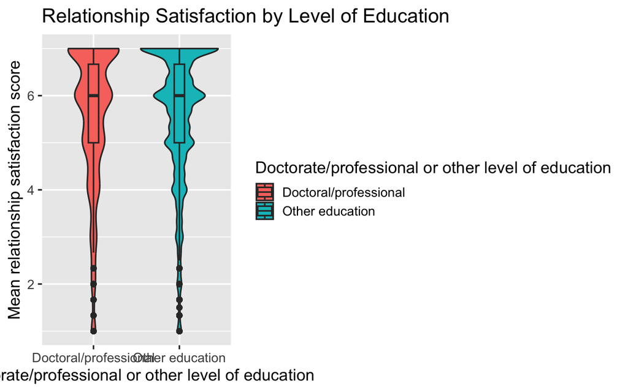

Figure 1: Average relationship satisfaction by degree group.

```r
h1Viol <- ggplot(data=h1Data,
                 aes(x= degreeGroup,
                     y= relSat,
                     fill= degreeGroup))+
  geom_violin()+
  geom_boxplot(width=.12)+
  labs(x="Doctorate/professional or other level of education",
       y="Mean relationship satisfaction score",
       fill="Doctorate/professional or other level of education",
       title="Relationship Satisfaction by Level of Education")+
  theme_gray(base_size=15)

h1Viol
```

## H2. Male time spent grooming hair and time spent on social media.

Male respondents who spend a lot of time grooming their hair daily will also report a lot of time spent on social media daily.

### Variables and descriptive statistics

- **Daily time spent grooming hair (Time_A_hair_1):** a single variable of each male respondents time spent grooming their hair daily between 0-360 minutes.

- **Daily time spent on social media (Time_social_media_1):** a single variable of each male respondents time spent on social media daily between 0-360 minutes.

This data set only includes respondents who answered “male” when asked for their sex at birth.

```r
summary(h2Data[, c("Time_A_hair_1", "Time_social_media_1")])
```

```
 Time_A_hair_1    Time_social_media_1
 Min.   :  0.00   Min.   :  0.0
 1st Qu.:  7.00   1st Qu.: 60.0
 Median : 15.00   Median :120.0
 Mean   : 36.83   Mean   :134.9
 3rd Qu.: 31.00   3rd Qu.:181.0
 Max.   :360.00   Max.   :360.0
```

### Graph

Figure 2 shows the relationship between male respondents’ time spent grooming their hair daily and time spent on social media daily. Points are jittered to make overlapping responses easier to see; the recorded scores are unchanged. The line summarizes the linear trend.

```r
nrow(h2Data)
```

```
[1] 23583
```

```r
nrow(unique(h2Data[,c("Time_A_hair_1","Time_social_media_1")]))
```

```
[1] 9017
```

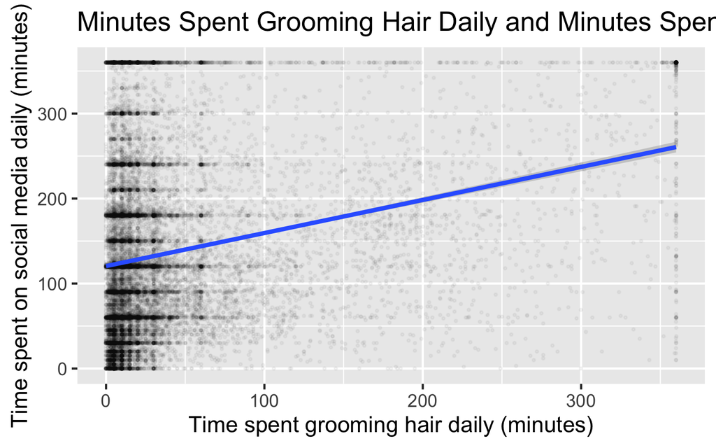

Figure 2: Daily time spent grooming hair and daily time spent on social media.

```r
h2Jitter <- ggplot(
  data=h2Data,
  aes(x= Time_A_hair_1,
      y= Time_social_media_1))+
  geom_jitter(width = .12,height=.04,alpha=.04,size = .6)+
  labs(x= "Time spent grooming hair daily (minutes)",
       y= "Time spent on social media daily (minutes)",
       title= "Minutes Spent Grooming Hair Daily and Minutes Spent on Social Media Daily")+
  theme_gray(base_size = 18)

h2Line <- h2Jitter + geom_smooth(method="lm")

h2Line
```

### Observed trend

```r
r <- cor(h2Data$Time_A_hair_1, h2Data$Time_social_media_1, use = "complete.obs")
round(r,2)
```

```
[1] 0.25
```

The correlation was 0.25, indicating a weak positive association. Male respondents who reported more time spent on grooming their hair daily reported more time spent on social media daily.